# Reproducible Research: Peer Assessment 1

## Loading and preprocessing the data

Unzip and load the data:

```r
unzip("activity.zip")
data <- read.csv("activity.csv")
```

## What is mean total number of steps taken per day?

Here is a histogram of the steps (using the base plotting system):

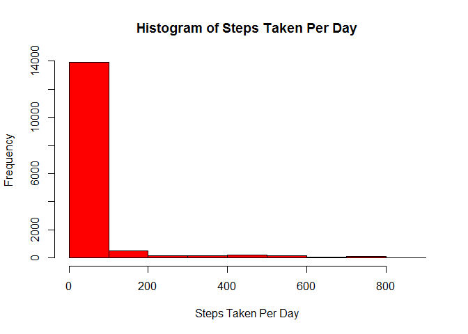

```r
hist(data$steps,
     breaks=10,
     col="red",
     main = "Histogram of Steps Taken Per Day",
     xlab = "Steps Taken Per Day",
     ylab = "Frequency")
```

```r
paste("mean:", mean(data$steps, na.rm=T), sep=" ")
```

[1] “mean: 37.3825995807128”

```r
paste("median:", median(data$steps, na.rm=T), sep=" ")
```

[1] “median: 0”

## What is the average daily activity pattern?

Here is a plot of the 5-minute interval and the average number of steps taken, averaged across all days:

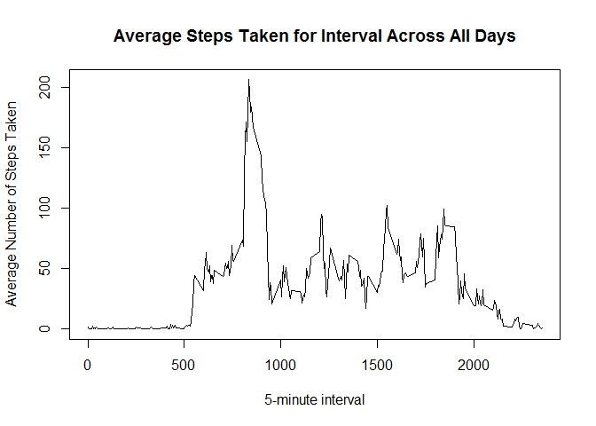

```r
group_data <- select(data, steps, interval)
plot_data <- as.data.frame(summarise(group_by(group_data, interval), mean(steps, na.rm=T)))
names(plot_data) <- c("interval", "mean")
plot(plot_data,
     type = "l",
     main = "Average Steps Taken for Interval Across All Days",
     xlab = "5-minute interval",
     ylab = "Average Number of Steps Taken")
```

The 5-minute interval, on average across all the days in the dataset, contains the maximum number of steps is:

```r
xtbl <- xtable(filter(plot_data, mean==max(plot_data$mean)))
print(xtbl, type="html", include.rownames=FALSE)
```

| interval | mean |
| --- | --- |
| 835 | 206.17 |

## Imputing missing values

Number of Steps that are NA (17,568 observations):

```r
df <- as.data.frame(table(is.na(data$steps)))
names(df) <- c("", "Count")
xtbl <- xtable(df)
print(xtbl, type="html", include.rownames=FALSE)
```

|  | Count |
| --- | --- |
| FALSE | 15264 |
| TRUE | 2304 |

Proportion of Steps that are NA (17,568 observations):

```r
df <- as.data.frame(prop.table(table(is.na(data$steps))))
names(df) <- c("", "%")
xtbl <- xtable(df)
print(xtbl, type="html", include.rownames=FALSE)
```

|  | % |
| --- | --- |
| FALSE | 0.87 |
| TRUE | 0.13 |

Replacing the NA’s with the mean for that 5-minute interval:

```r
data_new <- inner_join(data, plot_data, by="interval")
data_new$steps[is.na(data_new$steps)] <- data_new$mean[is.na(data_new$steps)]
data_new <- data_new[, c("steps", "date", "interval")]
```

Here is a histogram of the steps (using the base plotting system with imputed step counts):

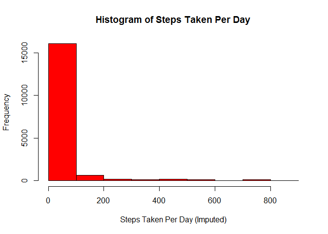

```r
hist(data_new$steps,
     breaks=10,
     col="red",
     main = "Histogram of Steps Taken Per Day",
     xlab = "Steps Taken Per Day (Imputed)",
     ylab = "Frequency")
```

```r
paste("mean:", mean(data_new$steps,), sep=" ")
```

[1] “mean: 37.3825995807128”

```r
paste("median:", median(data_new$steps), sep=" ")
```

[1] “median: 0”

```r
paste("mean: ", mean(data_new$steps) - mean(data_new$steps, na.rm=T), sep=" ")
```

[1] “mean: 0”

```r
paste("median: ", median(data_new$steps) - median(data_new$steps, na.rm=T), sep=" ")
```

[1] “median: 0”

## Are there differences in activity patterns between weekdays and weekends?

Comparing plots of the 5-minute interval and the average number of steps taken, averaged across all days, grouped by Weekday/Weekend (using the lattice plotting system):

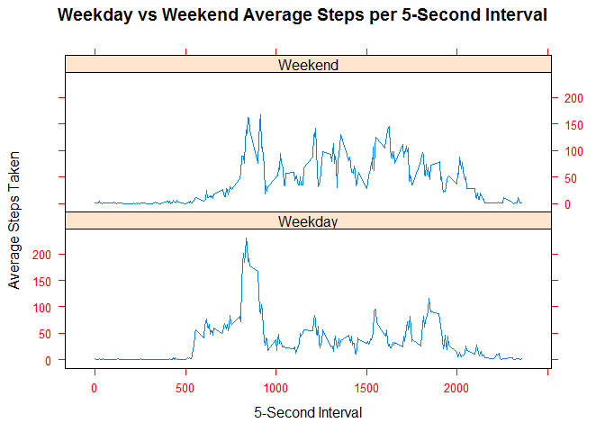

```r
data_new$weekday <- weekdays(as.Date(data_new$date), abbreviate=T)
data_new$w_flag <- "Weekday"
data_new$w_flag[data_new$weekday %in% c("Sat", "Sun")] <- "Weekend"
group_data_new <- select(data_new, steps, interval, w_flag)
plot_data_new <- as.data.frame(summarise(group_by(group_data_new,
                                                  interval, w_flag),
                                         mean(steps)))
names(plot_data_new) <- c("interval", "w_flag", "mean")
xyplot(mean~interval|w_flag,
       data=plot_data_new,
       type = "l",
       scales=list(cex=.8, col="red"),
       xlab="5-Second Interval",
       ylab="Average Steps Taken",
       main="Weekday vs Weekend Average Steps per 5-Second Interval",
       layout=c(1,2))
```